# Quantized model and quantize command

- [ Index ]
- Introduction
  - Quantized models
  - Quantized tensors
  - TFlite models
- Quantize command
  - Overview
  - Examples
  - Post-training quantization configuration file
  - Keras Post-training quantization process
  - Test-set considerations
  - Quantizers
  - Tensor format configuration file
  - Quantize a MNIST model
- References

# Quantized model and quantize command

X-CUBE-AI Expansion Package

r3.0

AI PLATFORM r7.0.0 (Embedded Inference Client API 1.1.0)

Command Line Interface r1.5.1

# Introduction

## Quantized models

X-CUBE-AI code generator can be used to deploy a quantized model (8b integer format). Quantization (also called calibration) is an optimization technique to compress a 32-bit floating-point model by reducing the size (smaller storage size and less memory peak usage at runtime), by improving CPU/MCU usage and latency (including power consumption) with a small degradation of accuracy. A quantized model executes some or all of the operations on tensors with integers rather than floating point values. It is an important part of various optimization techniques: topology-oriented, features-map reduction, pruning, weights compression… which can be applied to address the resource-constrained runtime environment.

There are two classical methods of quantization: post-training quantization and quantization aware training (QAT). First is relatively easier to use, it allows to quantize a pre-trained model with a limited and representative data set. Quantization aware training is done during the training process and is often better for model accuracy.

The CLI integrates an internal post-training quantization process (see “quantize” command section) with different quantization schemes for an already-trained Keras model.

[figure not shown]

X-CUBE-AI can import different type of quantized model:

- a Keras floating point model associated with its tensor format configuration file. The conversion of each 32b float weight/bias tensors to 8b integer format is directly achieved by the importer thanks to the provided settings.
- a quantized TensorFlow lite model (generated by a post-training or training aware process). In this case, the calibration has been performed by the TensorFlow Lite framework, principally through the “TFLite converter” utility exporting the TensorFlow lite file.

For a given operator, weights and activations should be quantized. Full 8b integer format is requested, **weights only or float16 TFLite quantization variants** are not supported. The mixed models with the convert operators (like QUANTIZE or DEQUANTIZE Tensor Lite operators), explicitly defined or automatically inserted by the X-CUBE-AI code generator are supported. Finally, the quantized tensors are mapped on the optimized and specialized C-implementation for the supported operators otherwise the floating-point version of the operator is used.

**Tip** — User has also the possibility to quantize a Keras model with the TFLite Converter utility and/or the X-CUBE-AI internal process. Despite the current limitations, this internal process offers more quantization schemes which can be more interesting in term of execution time and precision (i.e. accuracy). Results are fully dependent of the model size and associated topology. It provides also currently a better support to deploy a model with the recurrent layers which are kept in float w/o extra manipulation.

The “analyze”, “validate” and “generate” commands can be used w/o limitations. The `'-q/--quantize'` argument is used to pass the specific “tensor format configuration” file the associated reshaped Keras model.

```powershell
$ stm32ai analyze -m <reshaped_model_file>.h5 -q <quant_file_desc>.json
$ stm32ai analyze -m <quantized_model_file>.tflite
$ stm32ai validate -m <quantized_model>.tflite -vi test_data.npz
```

## Quantized tensors

X-CUBE-AI supports only 8b integer-base arithmetic for the quantized tensors (`'int8'` or `'uint8'` C-type). `'int32'` C-type is only considered for the quantization of the bias. The support of the *Qm,n* arithmetic is now fully removed.

The **integer** arithmetic is based on a representative convention used by Google for the quantized models. See the following reference to highlight the underlying rational.

- Quantization and Training of Neural Networks for Efficient Integer-Arithmetic-Only Inference (https://arxiv.org/abs/1712.05877)

Each real number *r* is represented in function of the quantized value *q*, a *scale* factor (*arbitrary positive real number*) and a *zero_point* parameter. Quantization scheme is an affine mapping of the integers *q* to real numbers *r*. *zero_point* has the same integer C-type like the *q* data.

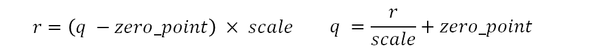

Precision is dependent of a *scale* factor and the quantized values are linearly distributed around the *zero_point* value. In both case, resolution/precision is constant vs floating-point representation.

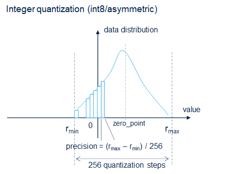

Figure 1: Integer precision

**Info** — For the code generator, quantized tensors are defined as a container storing the quantized data, represented as int8/uint8/int32 C-array and the quantization parameters: *scale* and *zero-point* values. These parameters are statically defined in the tensor C-structure definition, `ai_tensor` object (part of the generated `'<network>.c'` file) and the data are stored in the `'<network>_data.c'` file.

### Per-axis (or per-channel) vs per-tensor

Per-tensor means that the same format (i.e. *scale*/*zero_point*) is used for the entire tensor. Per-axis (or per-channel) for conv-base operator means there will be one *scale* and/or *zero_point* per slice.

Activation tensors are always in **per-tensor**.

### Symmetric vs Asymmetric

*Asymmetric* means that the tensor can have *zero_point* anywhere within the signed 8b range [-128, 127] or unsigned 8b range [0, 255]. *Symmetric* means that the tensor is forced to have *zero_point* equal to zero. By enforcing *zero_point* to zero, some kernel optimization implementations are possible to limit the cost of the operations (off-line pre-calculation,…). By nature, the activations are asymmetric, consequently symmetric format for the activations is not supported. For the weights/bias, asymmetric and symmetric format are supported.

### Signed integer vs Unsigned integer - supported schemes

Signed or unsigned integer type can be defined for the weights and/or activations. However all requested kernels are not implemented or relevant to support the different optimized combinations related to the symmetric and asymmetric format. This imply that *only* the following integer schemes or combinations are supported:

| scheme | weights | activations |
| --- | --- | --- |
| ua/ua | unsigned and asymmetric | unsigned and asymmetric |
| ss/sa | signed and symmetric | signed and asymmetric |
| ss/ua | signed and symmetric | unsigned and asymmetric |

## TFlite models

X-CUBE-AI is able to import the quantization training-aware and post-training quantized TensorFlow lite models. Post-training quantized models (TensorFlow v1.15 or v2.x) are based on the “ss/sa” and per-channel scheme. Activations are asymmetric and signed (int8), weights/bias are symmetric and signed (int8). Previous quantized training-aware models are based on the “ua/ua” scheme, now the “ss/sa” and per-channel scheme is also the privileged scheme to address efficiently the [Coral Edge TPUs](https://coral.ai/docs/edgetpu/models-intro/#compatibility-overview) or [TensorFlow Lite for Microcontrollers](https://www.tensorflow.org/lite/microcontrollers) runtime.

For X-CUBE-AI, following code snippet illustrates the recommended *TFLiteConverter* options to enforce full integer post-training quantization for all operators including the input/output tensors.

**Note** — Quantization of the input or/and output tensors are optional. They can be conserved in float for convenience and deployment facility, for example to keep the pre or/and post-processes in float.

```python
def representative_dataset_gen():
  data = tload(...)

  for _ in range(num_calibration_steps):
    # Get sample input data as a numpy array in a method of your choosing.
    input = get_sample(data)
    yield [input]

converter = tf.lite.TFLiteConverter.from_keras_model_file(<keras_model_path>)
converter.representative_dataset = representative_dataset_gen
# This enables quantization
converter.optimizations = [tf.lite.Optimize.DEFAULT]
# This ensures that if any ops can't be quantized, the converter throws an error
converter.target_spec.supported_ops = [tf.lite.OpsSet.TFLITE_BUILTINS_INT8]
# For full integer quantization, though supported types defaults to int8 only
converter.target_spec.supported_types = [tf.int8]
# These set the input and output tensors to uint8 (added in r2.3)
converter.inference_input_type = tf.uint8  # or tf.int8/tf.float32
converter.inference_output_type = tf.uint8  # or tf.int8/tf.float32
quant_model = converter.convert()

# Save the quantized file
with open(<tflite_quant_model_path>, "wb") as f:
    f.write(quant_model)
...
```

- Post-training quantization: https://www.tensorflow.org/lite/performance/post_training_quantization
- Quantization aware training: https://www.tensorflow.org/model_optimization/guide/quantization/training

# Quantize command

## Overview

The “quantize” command allows to perform a post-training quantization process on a 32b float Keras model. A reshaped Keras model and associated tensor format configuration are generated. Options are passed through a post-training quantization configuration json file (`'-q/--quantize'` argument). This JSON file is generated because Keras h5 format does not provide natively a support to handle the params of quantization (or meta information). Note that the reshaped model file is basically an un-fused version of the original 32b float model which can be used as-is.

[figure not shown]

### Limitations

- residual or multi-branches model
- model with multiple inputs or outputs
- only channel last (NHWC) tensor representation is supported
- only the supported floating-point Keras operators (refer to [KERAS] article) can be quantized. Layers that are not supported for will be kept in floating point.

## Examples

- Perform the post-training quantization process on an already-trained floating-point Keras model.

  ```
  $ stm32ai quantize -q <conf_quant>.json
  ```

- Validate a Keras model after Keras post-training quantization

  ```
  $ stm32ai validate -m <reshaped_model_file>.h5 -q <quant_file_desc>.json -vi test_data.npz
  ```

- Generate the specialized c-files for a quantized Keras model.

  ```
  $ stm32ai generate -m <expanded_model_file>.h5 -q <quant_file_desc>.json
  ```

## Post-training quantization configuration file

The use the Keras post-training quantization process a configuration file (JSON dictionary) is requested with the following keys:

[output not shown]

Produced files:

- `<model_name>.h5` - reshaped model file
- `<model_name>_Q.json` - tensor format configuration file
- `<model_name>_reference.npz` - reference file

**Note** — For the “path_to_floatingpoint_h5”, “output_directory”, “modules_directory”, “quant_test_set_dir” and “evaluation_test_set_dir” keys if the values are not prefixed by `"./"` or `"/"`, path is relative to the location of the JSON file path. Otherwise, the path is absolute or relative to the current executing path where the stm32ai application is launched.

**Warning** —  
All fields are requested. Only the *“filename_quantizer_algos”* can be omitted if *“User”* algo is not selected.

**“quant_test_ratio” parameter**

If you have *1000* images in “quant_test_set_dir” and the user sets “quant_test_ratio” to *0.8* then only *800* images we be used from the quantization test-set. This parameter can be viewed as a way to control the execution time of the script that can be long depending on the user system, the size of the quantization test-set, the quantization algorithm and the depth of the network. Please, note that in case Keras pre-existing *ImageDataGenerator()* class is used to load data, then Keras constraints impose *“quant_test_ratio”* be strictly lower than *1*.

### Example of configuration files

Following configuration file, set the SS/SA scheme with per-channel quantization.

```json
{
        "model_name": "mnist",
        "path_to_floatingpoint_h5": "mnist_cnn.h5",
        "batch_size": "128",
        "quant_test_set_dir": ".\\",
        "quant_test_ratio": "0.3",
        "evaluation_test_set_dir": "",
        "modules_directory": "mnist_modules",
        "filename_test_set_generation": "test_set_generation",
        "filename_quantizer_algos": "quantizer_user_algo",
        "algorithm": "MinMax",
        "arithmetic": "Integer",
        "weights_integer_scheme": "SignedSymmetric",
        "activations_integer_scheme": "SignedAsymmetric",
        "output_directory": "out",
        "per_channel": "true",
}
```

## Keras Post-training quantization process

The Keras post-training quantization process goes through the following steps. For all selected algo or quantized scheme, the same flow is applied.

**Warning** — Internally the algorithm is fully based on the tf.keras module from the TensorFlow v2.x. It allows to import the h5 file generated with the original Keras module v2.x up to v2.3.1 and also with the tf.keras from TensorFlow v1.15. Consequently, it is recommended to use also the services from the tf.keras module to design the user modules (`test_set_generation.py` and `quantizer_user_algo.py` modules) avoiding possible incompatible situation.

[figure not shown]

Figure 2: Quantization steps

**[1.0]** - Load the *evaluation test-set*, *quantization test-set* and original model (see *“Test-set considerations”* section). Note that the Keras *load_model()* v2.2.4 function is used to load the original model.

```powershell
Neural Network Tools for STM32AI v1.4.1 (STM.ai v6.0.0)

Output directory    : <output_directory>
Module directory    : <modules_directory>
Test directory      : <tests_directory>
Eval directory      : <eval_directory>
Original model      : <path_to_floatingpoint_h5>
Quantization algo   : minmax
Arithmetic          : Integer
Scheme  (w-a)       : SS-SA-per-tensor

-- Loading/Initializing dataset
-- Loading/Initializing dataset - done (elapsed time 0.016s)
```

**[1.1]** - Accuracy of the original model is evaluated with the *evaluation test-set*. The Keras *mean_squared_error* function is used as loss function. If no ground truth or reference values are provided, this step is skipped.

```powershell
-- Testing original model
 Original model - test accuracy (loss): 0.9943 (0.00103)
-- Testing original model - done (elapsed time 0.837s)
```

**[1.2]** - Automatic **reshape** of the original model (see *“Supported Keras layers”* section).

- split a SeparableConv2D into a DepthwiseConv2D followed by a Pointwise Conv2D.
- un-fuse activations whenever they are merged into a trainable layer in the original floating-point model
- folding of Batch normalization weights (if there is no non-linearity between Batch-Norm and previous trainable layer). If folded, the Batch-norm layer no longer appears in the reshaped model. If Batch-norm cannot be folded, it will be automatically kept in floating point and following message is displayed:

```powershell
...
Batch normalisation layer #9 of output model was not folded into previous layer weights
Reason: layer #8 'Activation' is not supported for possible BatchNormalization folding
    supported layers: ('Dense', 'Conv2D', 'DepthwiseConv2D', 'SeparableConv2D', 'Conv1D',
        'SeparableConv1D')
...
```

```powershell
-- Reshaping original model
 unroll the SeparableConv2D layers...
 unfuse activations...
 fold the BatchNormalization layers...
-- Reshaping original model - done (elapsed time 1.225s)
```

**[1.3]** - Accuracy of the reshaped model is evaluated with the *evaluation test-set*. If no ground truth or reference values are provided, this step is skipped.

**Note** — The modified network is expected to be mathematically equivalent to the original model.

```powershell
-- Testing reshaped model
 Reshaped model - test accuracy (loss): 0.9943 (0.00103)
-- Testing reshaped model - done (elapsed time 0.590s)
```

**[1.4]** - Save the reshaped model (`h5*` file creation)

```powershell
-- Saving re-shaped model
create "mnist_ss_sa_pc.h5" file
-- Saving re-shaped model - done (elapsed time 0.216s)
```

**[2.0]** - **Quantize the weights**: original weights are quantized, by default with the *“minmax”* algo. If *“User”* algorithm is set, the *WeightsBiasQuantizerUser()* function from the user *“filename_quantizer_algos.py”* module is imported and used (see *“Quantizers”*). After this step, a function replaces the original weights of the reshaped model with “fake quantized” weights. Note that no *evaluation test-set* or *quantization test-set* or iterative algo are used.

```powershell
-- Quantizing weights with "minmax" algo
-- Quantizing weights with "minmax" algo - done (elapsed time 0.256s)
```

**[2.1]** - **Quantize the activations** by passing the *quantization test-set*. If *“User”* algorithm is set, the *ActivationsQuantizerUser()* function from the user *“filename_quantizer_algos.py”* module is imported and used (see *“Quantizers”*))

```powershell
-- Quantizing activations with "minmax" algo
 create "mnist_ss_sa_pc_Q.json" file
-- Quantizing activations with "minmax" algo - done (elapsed time 1.136s)
```

**[2.2]** - Create and save the tensor format configuration file.

**Tip** — By default, if a Softmax layer is part of the network, it is automatically keep in float.

**[3.0]** - Evaluate the accuracy of the quantized model on the *evaluation test-set*. If no ground truth or reference values are provided, this step is skipped.

```powershell
-- Testing final quantized model
 Final quantized model - test accuracy (loss): 0.9943 (0.00101)
-- Testing final quantized model - done (elapsed time 0.824s)
```

**Note** — As Keras layers do not support quantized values, the behavior of the quantized layers is emulated by quantizing and then rescaling back to float the tensor values; this process is often called **“fake_quantization”**. The quantization changes significantly the outputs of the network and thus you cannot use the original model to validate its result; however, the script generates reference input and outputs you can use with **X-CUBE-AI**’s validation (see next section).

**[3.1]** - If available, save a batch of inputs (“batch_size”) and the predicted values of the quantized model. It can be used as reference to valid the generated C-model.

**[3.2]** - Produced files

```powershell
<output_directory>/<model_name>_<algorithm>_<date>_<time>/final_accuracy.txt
<output_directory>/<model_name>_<algorithm>_<date>_<time>/<model_name>.h5
<output_directory>/<model_name>_<algorithm>_<date>_<time>/<model_name>_Q.json
<output_directory>/<model_name>_<algorithm>_<date>_<time>/<model_name>_reference.npz
```

#### Validation on desktop

Following command can be used to evaluate the quantized model with the generated x86 C-model (refer to [METRIC] about the evaluated metrics).

```powershell
$ stm32ai validate <model_name>.h5 -q <model_name>_Q.json -vi <model_name>_reference.npz
Neural Network Tools for STM32AI v1.4.1 (STM.ai v6.0.0)
 ...
 model file         : <reshaped_model_name>.h5
 type               : keras
 c_name             : network
 compression        : None
 quantize           : <model_name>_Q.json
 workspace dir      : <workspace-directory-path>
 output dir         : <output-directory-path>
 vinput files       : <model_name>_reference.npz
 ...
input              : quantize_conv2d_1_input [784 items, 784 B, ai_i8,
                         scale=0.00392156862745098, zero_point=-128, (28, 28, 1)]
inputs (total)     : 784 B
output             : softmax_8 [10 items, 40 B, ai_float, FLOAT32, (1, 1, 10)]
outputs (total)    : 40 B
params #           : 1,199,882 items (4.58 MiB)
macc               : 12,029,716
weights (ro)       : 1,200,584 B (1172.45 KiB) -3,598,944(-75.0%)
activations (rw)   : 32,704 B (31.94 KiB)
ram (total)        : 33,528 B (32.74 KiB) = 32,704 + 784 + 40


...
Evaluation report (summary)
---------------------------------------------------------------------------------- ...
Mode                acc       rmse          mae           l2r           tensor
---------------------------------------------------------------------------------- ...
x86 C-model #1      100.00%   0.000000002   0.000000000   0.000000007   softmax_8, ...
original model #1   100.00%   0.001213685   0.000121268   0.003879170   softmax_8, ...
X-cross #1          100.00%   0.001213685   0.000121268   0.003878688   softmax_8, ...
---------------------------------------------------------------------------------- ...
...
```

## Test-set considerations

The quantization process gives the possibility to load batches of test vectors. The quantization requires the knowledge of the range of the values of all the tensors. The weights are constant and thus their range is easy to estimate, whereas the *activation’s range* depends on the input data. An accurate estimate of the activation range requires a test set representative of real data:

- it means a balanced test set over all the labels to be classified
- test set should be large enough to reflect how variable can be the network inputs and thus to be as representative as possible

We call it **quantization test-set**. If this test-set is too small, not representative enough or even unbalanced, quantization will be performed as usual but there is a risk that the quantized model performance be not satisfying. The other test-set, called *evaluation test-set*, is used to assess performance of floating point model and quantized model and potentially compare them. The **evaluation test-set** and the **quantization test-set** should be as independent as possible to avoid over-estimation of the quantized model performance.

The input vectors is loaded with the *create_test_generator()* function which is dynamically imported by the core from the user *“filename_test_set_generation.py”* module. Preprocessing or adaptation of the loaded data should be done in this function (see *“Quantize a NMIST model”* sections).

```python
def create_test_generator(quant_test_set_dir, evaluation_test_set_dir,
                          quant_test_ratio, batch_size)
```

**Note** — If the neural network is not used for a classification task, or if labels are not available for the quantizer then in the *create_test_generator()* function set `quant_test_set_labeled` to `None` and `eval_test_set_labeled` to `None`.

## Quantizers

One default quantizer (also called algorithm) can be used to generate the tensor format configuration file: *“Minmax”* . The user (*“User”* algorithm) has also the possibility to provide its own quantization method with different compromises between quantized data precision and saturation, by implementing the *estimate* method in the quantizer class and passing it to the functions for weight and activation quantization (see *“filename_quantizer_algos.py”* user module).

- *“Minmax”* invokes the simple and quick quantization process based on min and max of all the tensors for weights and activations. The *quantization test-set* is used to estimate the activation ranges. The weights are constant and thus their ranges are directly estimated.

**Note** — Whatever the algorithm used, the quantizer script issues the quantized model expected accuracy on the *evaluation test-set* (if labels are present). This is an interesting indication, that may be used to compare different quantizers but the recommendation is to verify that the quantized model generalize well-enough according to your requirements. This has to be done with real *field* inputs.

## Tensor format configuration file

The proprietary *tensor format configuration* file is a JSON dictionary giving the expected tensor format. One entry is defined for each quantized tensor. If a tensor is omitted, the format is float by default (unless it is inferred). As a result, there is no way to indicate that a tensor format is float. The configuration is provided as a JSON file generated from the network structure and it is specific to a neural network model.

```json
{
    "version": "2.0",
    "<layer_type>_<idx>_<tensor_name>": {
        "format": {
            "class": "Integer",
            "type": "S8",
            "params": [ [ 0.0019106452371559892 ],[ 132 ] ],
        }
    },
}
```

| field | description |
| --- | --- |
| version | version/format of the JSON file |
| name | `<layer_type>`: name/type of tf.keras layer, `<idx>`: position of the layer in the Keras network, `<tensor_name>`: designates the conventional name of the associated tensor: “out”, “weights”, “bias”. |
| format.class | indicates the arithmetic format: can be “FXP” (for “Qmn”) or “Integer” |
| format.type | indicates the type of data: “U8”, “S8” or “S32” (bias in integer) |
| format.params | indicates the parameters: “FXP”: [number of integer bits (M), number of fractional bits (N)] “Integer”: [[scale value], [zero_point value]] |

In case of per channel, the output JSON file may look like this for example with 8 output channels layer whose weights are quantized in UnsignedAsymmetric:

```json
{
    "version": "2.0",
    "<layer_type>_<idx>_<tensor_name>": {
        "format": {
            "class": "Integer",
            "type": "U8",
            "params": [
                [
                    0.0018906078235370906,
                    0.0021662522019363765,
                    0.0017604492311402568,
                    0.0015629781043435644,
                    0.0019880688096594623,
                    0.002500925711759432,
                    0.0019362337711289173,
                    0.0016825192087278592,
                ],
                [
                    132,
                    150,
                    120,
                    165,
                    23,
                    88,
                    230,
                    129,
                ]
            ],
        }
    },
}
```

Qmn example

```json
{
    "version": "2.0",
    "Input": {
        "format": {
            "type": "S8",
            "class": "FXP",
            "params": [ 0, 7]
        }
    },
}
```